# DNA Metabarcoding Highlights Cyanobacteria as the Main Source of Primary Production in a Pelagic Food Web Model - Supplementary information: Model analysis

### Create a paired data set, with each OTU in both the water and gut sample on one row.

```r
environment <- zoopl_16S %>%
  # Select Water samples only
  dplyr::filter(NODE_NAME == "Water")


paired_data <- zoopl_16S %>%

  # Select gut samples only
  dplyr::filter(NODE_NAME != "Water") %>%

  # Merge the Zooplankton and the water dataset, on the OTU level.
  dplyr::left_join(environment, by="OTU") %>%

  # Remove OTUs with no read in the water sample.
  dplyr::filter(is.na(Sample.y)==FALSE,
         Abundance.y>0)

head(paired_data)
```

|  | OTU | Sample.x | SORTED_genus.x | SAMPLE_date.x | Domain.x | Supergroup.x | Phylum.x | Class.x | Order.x | Family.x | Genus.x | Species.x | STATION_ID.x | Abundance.x | StationDate.x | StationDateOTU.x | NODE_NAME.x | Sample.y | SORTED_genus.y | SAMPLE_date.y | Domain.y | Supergroup.y | Phylum.y | Class.y | Order.y | Family.y | Genus.y | Species.y | STATION_ID.y | … |
| --- | --- | --- | --- | --- | --- | --- | --- | --- | --- | --- | --- | --- | --- | --- | --- | --- | --- | --- | --- | --- | --- | --- | --- | --- | --- | --- | --- | --- | --- | --- |
| 1 | AGGAATTTTCCGCAATGGGCGAAAGCCTGACGGAGCAATACCGCGTGGAGGATGAAGGCC…… | P19201_1077 | Acartia | 2020-09-09 | Chloroplast | Excavata | Discoba | Euglenozoa | Euglenales | Euglenaceae | Colacium | Colacium_sp. | By2 | 0.9579288 | By2 2020-09-09 | By2 2020-09-09 AGGAATTTTCCGCAATGGGCGAAAGCCTGACGGAGCAATACCGCGTGGAGGATGAAGGCCCTTGGGTTGTAAACTTCTTTTACCACTGAGGAATATTGACAGTAGGTGGTGAATAAGCACCGGCTAATTTCGTGCCAGCAGCCGCGGTAATACGAGAGGTGCAAGCGTTATTCGGATTTATTGGG… | Acartia | By2 2020-09-09 | Water | NA | Chloroplast | Excavata | Discoba | Euglenozoa | Euglenales | Euglenaceae | Colacium | Colacium_sp. | NA | … |
| 2 | AGGAATTTTCCGCAATGGGCGAAAGCCTGACGGAGCAATACCGCGTGGAGGATGAAGGCC…… | P19201_1077 | Acartia | 2020-09-09 | Chloroplast | Excavata | Discoba | Euglenozoa | Euglenales | Euglenaceae | Colacium | Colacium_sp. | By2 | 0.9579288 | By2 2020-09-09 | By2 2020-09-09 AGGAATTTTCCGCAATGGGCGAAAGCCTGACGGAGCAATACCGCGTGGAGGATGAAGGCCCTTGGGTTGTAAACTTCTTTTACCACTGAGGAATATTGACAGTAGGTGGTGAATAAGCACCGGCTAATTTCGTGCCAGCAGCCGCGGTAATACGAGAGGTGCAAGCGTTATTCGGATTTATTGGG… | Acartia | By2 2019-06-01 | Water | NA | Chloroplast | Excavata | Discoba | Euglenozoa | Euglenales | Euglenaceae | Colacium | Colacium_sp. | NA | … |
| 3 | GGGAATTTTCCGCAATGGGCGAAAGCCTGACGGAGCAATACCGCGTGAGGGAGGAAGGCT…… | RD-1794-Oa404_S95 | Acartia | 2018-03-19 | Bacteria | Cyanobacteria | Oxyphotobacteria | Nostocales | Nostocales | Nostocaceae | Nostocaceae | Nostocaceaex | By31 | 0.9548387 | By31 2018-03-19 | By31 2018-03-19 GGGAATTTTCCGCAATGGGCGAAAGCCTGACGGAGCAATACCGCGTGAGGGAGGAAGGCTCTTGGGTTGTAAACCTCTTTTCTCAGGGAAGAACAGAATGACGGTACCTGAGGAATAAGCATCGGCTAACTCCGTGCCAGCAGCCGCGGTAATACGGAGGATGCAAGCGTTATCCGGAATGATT… | Acartia | By31 2018-08-27 | Water | NA | Bacteria | Cyanobacteria | Oxyphotobacteria | Nostocales | Nostocales | Nostocaceae | Nostocaceae | Nostocaceaex | NA | … |
| 4 | GGGAATTTTCCGCAATGGGCGAAAGCCTGACGGAGCAATACCGCGTGAGGGAGGAAGGCT…… | RD-1794-Oa404_S95 | Acartia | 2018-03-19 | Bacteria | Cyanobacteria | Oxyphotobacteria | Nostocales | Nostocales | Nostocaceae | Nostocaceae | Nostocaceaex | By31 | 0.9548387 | By31 2018-03-19 | By31 2018-03-19 GGGAATTTTCCGCAATGGGCGAAAGCCTGACGGAGCAATACCGCGTGAGGGAGGAAGGCTCTTGGGTTGTAAACCTCTTTTCTCAGGGAAGAACAGAATGACGGTACCTGAGGAATAAGCATCGGCTAACTCCGTGCCAGCAGCCGCGGTAATACGGAGGATGCAAGCGTTATCCGGAATGATT… | Acartia | By31 2017-08-15 | Water | NA | Bacteria | Cyanobacteria | Oxyphotobacteria | Nostocales | Nostocales | Nostocaceae | Nostocaceae | Nostocaceaex | NA | … |
| 5 | GGGAATTTTCCGCAATGGGCGAAAGCCTGACGGAGCAATACCGCGTGAGGGAGGAAGGCT…… | RD-1794-Oa404_S95 | Acartia | 2018-03-19 | Bacteria | Cyanobacteria | Oxyphotobacteria | Nostocales | Nostocales | Nostocaceae | Nostocaceae | Nostocaceaex | By31 | 0.9548387 | By31 2018-03-19 | By31 2018-03-19 GGGAATTTTCCGCAATGGGCGAAAGCCTGACGGAGCAATACCGCGTGAGGGAGGAAGGCTCTTGGGTTGTAAACCTCTTTTCTCAGGGAAGAACAGAATGACGGTACCTGAGGAATAAGCATCGGCTAACTCCGTGCCAGCAGCCGCGGTAATACGGAGGATGCAAGCGTTATCCGGAATGATT… | Acartia | By31 2018-03-19 | Water | NA | Bacteria | Cyanobacteria | Oxyphotobacteria | Nostocales | Nostocales | Nostocaceae | Nostocaceae | Nostocaceaex | NA | … |
| 6 | GGGAATTTTCCGCAATGGGCGAAAGCCTGACGGAGCAATACCGCGTGAGGGAGGAAGGCT…… | RD-1794-Oa404_S95 | Acartia | 2018-03-19 | Bacteria | Cyanobacteria | Oxyphotobacteria | Nostocales | Nostocales | Nostocaceae | Nostocaceae | Nostocaceaex | By31 | 0.9548387 | By31 2018-03-19 | By31 2018-03-19 GGGAATTTTCCGCAATGGGCGAAAGCCTGACGGAGCAATACCGCGTGAGGGAGGAAGGCTCTTGGGTTGTAAACCTCTTTTCTCAGGGAAGAACAGAATGACGGTACCTGAGGAATAAGCATCGGCTAACTCCGTGCCAGCAGCCGCGGTAATACGGAGGATGCAAGCGTTATCCGGAATGATT… | Acartia | By31 2017-11-15 | Water | NA | Bacteria | Cyanobacteria | Oxyphotobacteria | Nostocales | Nostocales | Nostocaceae | Nostocaceae | Nostocaceaex | NA | … |

### Calculate Selectivity indices for each OTU and sample

```r
selectivity_data <- paired_data %>%

  # Calculate preference value based on water Rg(i)/Re(i)
  dplyr::mutate(Preference = Abundance.x/Abundance.y) %>%

  # Summarize per sample Preference/sum(prefeerence) ; RA(ij)/RA(iw) / sum(k, RA(kj)/RA(kw))
  dplyr::group_by(Sample.x) %>%
  dplyr::summarize(Selectivity_index=Preference/sum(Preference),
            OTU = OTU, NODE_NAME = NODE_NAME.x,
            Domain=Domain.x, Supergroup=Supergroup.x, Class = Class.x,
            Order=Order.x, Family=Family.x, Genus=Genus.x, Species=Species.x, SAMPLE_date=SAMPLE_date.x)

head(selectivity_data)
```

| Sample.x | Selectivity_index | OTU | NODE_NAME | Domain | Supergroup | Class | Order | Family | Genus | Species | SAMPLE_date |
| --- | --- | --- | --- | --- | --- | --- | --- | --- | --- | --- | --- |
| P12051_1001 | 0.004976406 | AGGAATTTTCCGCAATGGGCGAAAGCCTGACGGAGCAATGCCGCGTGGAGGAGGAAGGCC…… | Synchaeta | Chloroplast | Archaeplastida | Trebouxiophyceae | Trebouxiophyceae_XX | Coccomyxaceae | Chlorophyta | Chlorophyta_symbiont | 2017-06-19 |
| P12051_1001 | 0.007217436 | AGGAATTTTCCGCAATGGGCGAAAGCCTGACGGAGCAATGCCGCGTGGAGGAGGAAGGCC…… | Synchaeta | Chloroplast | Archaeplastida | Trebouxiophyceae | Trebouxiophyceae_XX | Coccomyxaceae | Chlorophyta | Chlorophyta_symbiont | 2017-06-19 |
| P12051_1001 | 0.011666541 | AGGAATTTTCCGCAATGGGCGAAAGCCTGACGGAGCAATGCCGCGTGGAGGAGGAAGGCC…… | Synchaeta | Chloroplast | Archaeplastida | Trebouxiophyceae | Trebouxiophyceae_XX | Coccomyxaceae | Chlorophyta | Chlorophyta_symbiont | 2017-06-19 |
| P12051_1001 | 0.022616282 | AGGAATTTTCCGCAATGGGCGAAAGCCTGACGGAGCAATGCCGCGTGGAGGAGGAAGGCC…… | Synchaeta | Chloroplast | Archaeplastida | Trebouxiophyceae | Trebouxiophyceae_XX | Coccomyxaceae | Chlorophyta | Chlorophyta_symbiont | 2017-06-19 |
| P12051_1001 | 0.023827427 | AGGAATTTTCCGCAATGGGCGAAAGCCTGACGGAGCAATGCCGCGTGGAGGAGGAAGGCC…… | Synchaeta | Chloroplast | Archaeplastida | Trebouxiophyceae | Trebouxiophyceae_XX | Coccomyxaceae | Chlorophyta | Chlorophyta_symbiont | 2017-06-19 |
| P12051_1001 | 0.028474270 | AGGAATTTTCCGCAATGGGCGAAAGCCTGACGGAGCAATGCCGCGTGGAGGAGGAAGGCC…… | Synchaeta | Chloroplast | Archaeplastida | Trebouxiophyceae | Trebouxiophyceae_XX | Coccomyxaceae | Chlorophyta | Chlorophyta_symbiont | 2017-06-19 |

### Summarize Selectivity indices for sample replicates and OTUs.

```r
summarized_selectivity <- selectivity_data %>%

  # Mean Si for all OTUs for sample replicates.
  dplyr::group_by(NODE_NAME, Class, Order, Family, Genus, Species, OTU, SAMPLE_date) %>%
  dplyr::summarise(Selectivity_index= mean(Selectivity_index)) %>%

  # Merge OTUs at suitable level. (Here, Class)
  dplyr::group_by(NODE_NAME, Order, SAMPLE_date) %>%
  dplyr::summarise(Selectivity_index= sum(Selectivity_index)) %>%

  #Filter uniportant contributions
  dplyr::filter(Selectivity_index > 0.00) %>%
  dplyr::group_by(NODE_NAME, SAMPLE_date) %>%
  dplyr::summarize(Selectivity_index=Selectivity_index/sum(Selectivity_index), Order)

head(summarized_selectivity)
```

| NODE_NAME | SAMPLE_date | Selectivity_index | Order |
| --- | --- | --- | --- |
| Acartia | 2017-06-19 | 0.003671528 | Archaeplastidaxxxx |
| Acartia | 2017-06-19 | 0.627696404 | Chaetocerotales |
| Acartia | 2017-06-19 | 0.005790936 | Chlorellales |
| Acartia | 2017-06-19 | 0.046348025 | Chloroplastxxxxx |
| Acartia | 2017-06-19 | 0.004583081 | Eustigmatales |
| Acartia | 2017-06-19 | 0.285390459 | Nostocales |

```r
rm(environment, paired_data, selectivity_data, zoopl_16S)
```

## 1.2 Biomasses

The population biomasses of zooplankton and phytoplankton were retrieved from the Swedish national pelagic phytoplankton and zooplankton monitoring with sampling intensity ranging between monthly and weekly samples(51). Individual body masses of phytoplankton and zooplankton were retrieved from COMBINE guidelines for plankton monitoring in the Baltic Sea(52). We calculated daily biomass estimates over one year by linearly interpolating data from samples taken between 2007 and 2018.

```r
Zooplankton <- readRDS("Data/Zooplankton_shark.rds")
Phytoplankton <- readRDS("./Data/Phytoplankton_shark.rds")
```

### Daily interpolation of biomass

We calculated daily biomass estimates by linearly interpolating data from samples taken between 2007 and 2018. First we define the function for daily interpolation:

```r
dailyInterpretation <- function(data, taxa="Genus") {

  require(tidyverse, xts)

  allDates <- seq.Date(
    #Creating a sequence of days for dataset
    min(as.Date(data$SDATE)),
    max(as.Date(data$SDATE)),
    "day")


  daydata <- data %>%

    # Turn into "matrix" format
    spread(key={{taxa}}, value=Value) %>%

    # Replaceing Nas with 0 for actual samples
    replace(is.na(.), 0) %>%

    # Adding the sequence of days to existing dataset
    full_join(x=data.frame(SDATE=allDates), y=.) %>%

    # Order acc to date
    arrange(SDATE) %>%

    # Linnear na approximation of all numeric variables in dataset
    mutate_if(is.numeric, funs(na.approx(.))) %>%

    # Back to long format
    gather(key = "Taxa", colnames(.)[-1], value = "Value") %>%

    # Summarize days of each year
    mutate(Abundance = as.numeric(as.character(Value)),
           DOY = as.numeric(strftime(SDATE, format = "%j")),
           Year = as.numeric(strftime(SDATE, format = "%Y"))) %>%
    group_by(DOY, Taxa) %>%
    summarize(Abundance = mean(Abundance))

  return(daydata)
}
```

### Daily interpolation of zooplankton biomass

```r
dip_zooplankton <- function(x) {

zoopl <- Zooplankton %>%
  dplyr::filter(Station == x,
        Depth %in% c(30,60),
         Year > 2006,
         Parameter == "Wet weight/volume",
         dev_stage_code != "NP",
         Genus %in% c(
           "Evadne",
           "Bosmina",
           "Acartia",
           "Temora",
           "Centropages",
           "Keratella",
           "Synchaeta",
           "Pseudocalanus"
           )) %>%
  group_by(SDATE, Genus) %>%

  summarize(Value=sum(Value)*30/1000) %>% # *30 To get the full water column, /1000 to get from mg to g.

  dailyInterpretation(taxa="Genus") %>%
  mutate(NODE_NAME=Taxa,
         Station=x)

  return(zoopl)
}

zooplankton_dip <- dip_zooplankton("BY31 LANDSORTSDJ") %>%
  bind_rows(dip_zooplankton("BY15 GOTLANDSDJ")) %>%
  bind_rows(dip_zooplankton("BY5 BORNHOLMSDJ"))


head(zooplankton_dip)
```

| DOY | Taxa | Abundance | NODE_NAME | Station |
| --- | --- | --- | --- | --- |
| 1 | Acartia | 0.3577476702 | Acartia | BY31 LANDSORTSDJ |
| 1 | Bosmina | 0.0396388453 | Bosmina | BY31 LANDSORTSDJ |
| 1 | Centropages | 0.2147629627 | Centropages | BY31 LANDSORTSDJ |
| 1 | Evadne | 0.0022328321 | Evadne | BY31 LANDSORTSDJ |
| 1 | Keratella | 0.0002149952 | Keratella | BY31 LANDSORTSDJ |
| 1 | Pseudocalanus | 0.3106099186 | Pseudocalanus | BY31 LANDSORTSDJ |

### Daily interpolation of phytoplankton

```r
dip_phytoplankton <- function(x) {


phytopl <- Phytoplankton %>%

  filter(Station == x,
         Year > 2006,
         unit ==    "ugC/l") %>%

  group_by(SDATE, Order, Depth) %>%
  summarize(Value=sum(Value)) %>%

  group_by(SDATE, Order) %>%
  summarize(Value=mean(Value)*0.12) %>%
  # *0.12 to correct for depth *30, carbon content*4, and parameter *0.001 ug/l -> g/m

  dailyInterpretation(taxa="Order") %>%
  mutate(NODE_NAME=Taxa,
         Station=x)
}

phytoplankton_dip <- dip_phytoplankton("BY31 LANDSORTSDJ") %>%
  bind_rows(dip_phytoplankton("BY15 GOTLANDSDJ")) %>%
  bind_rows(dip_phytoplankton("BY5 BORNHOLMSDJ"))

head(phytoplankton_dip)
```

| DOY | Taxa | Abundance | NODE_NAME | Station |
| --- | --- | --- | --- | --- |
| 1 |  | 2.749571e-02 |  | BY31 LANDSORTSDJ |
| 1 | Bacillariales | 3.887736e-05 | Bacillariales | BY31 LANDSORTSDJ |
| 1 | Chaetocerotales | 4.350544e-03 | Chaetocerotales | BY31 LANDSORTSDJ |
| 1 | Chlorellales | 1.545240e-03 | Chlorellales | BY31 LANDSORTSDJ |
| 1 | Chlorodendrales | 0.000000e+00 | Chlorodendrales | BY31 LANDSORTSDJ |
| 1 | Chromulinales | 0.000000e+00 | Chromulinales | BY31 LANDSORTSDJ |

```r
NA
```

## 1.3 Combine data sets to Links and Edges

In this section we match the different data sources to create a data frame describing the edges (organism groups) of the food web, and one matrix describing the links (feeding selectivity) of the edges.

### Filter and merge biomass data

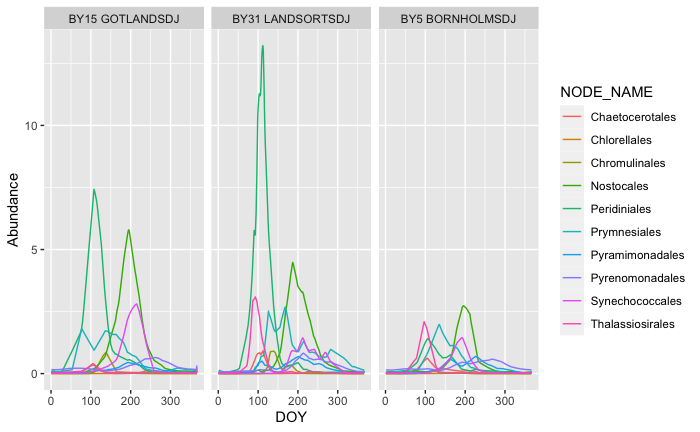

```r
# List prey orders detected in zooplankton guts
zp_prey <- summarized_selectivity %>%
  pull(Order) %>%
  unique()

# Filter biomass data by detected prey only
phytoplankton_abundance <- phytoplankton_dip %>%
  filter(NODE_NAME %in% zp_prey) %>%
  select(DOY, Abundance, NODE_NAME, Station)

# Plot all sources per station
phytoplankton_abundance %>%
ggplot(aes(DOY, Abundance)) +
  geom_line(aes(color=NODE_NAME)) +
  facet_wrap(~Station)
```

```r
head(phytoplankton_abundance)
```

| DOY | Abundance | NODE_NAME | Station |
| --- | --- | --- | --- |
| 1 | 0.004350544 | Chaetocerotales | BY31 LANDSORTSDJ |
| 1 | 0.001545240 | Chlorellales | BY31 LANDSORTSDJ |
| 1 | 0.000000000 | Chromulinales | BY31 LANDSORTSDJ |
| 1 | 0.068479442 | Nostocales | BY31 LANDSORTSDJ |
| 1 | 0.034747961 | Peridiniales | BY31 LANDSORTSDJ |
| 1 | 0.136659809 | Prymnesiales | BY31 LANDSORTSDJ |

```r
Biomasses <- zooplankton_dip %>%
  select(DOY, Abundance, NODE_NAME, Station) %>%
  union(phytoplankton_abundance)
```

### Filter selectivity data, Links

```r
# List potential prey that is detected or monitored in the water microscopically
pp <- phytoplankton_abundance %>%
  pull(NODE_NAME) %>%
  unique()

# Filter selectivity dataset by prey availability
Links <- summarized_selectivity %>%
  filter(Order %in% pp) %>%
  mutate(Predator = NODE_NAME, Prey = Order) %>%
  group_by(Predator, Prey) %>%
  summarise(Preference = mean(Selectivity_index))

# Save Selectivity index table
pivot_wider(Links, names_from = Prey, values_from = Preference, values_fill = 0) %>%
  relocate(c("Predator",rev(ord.prey.fw))) %>%
  arrange(match(Predator, ord.pred.fw)) %>%

  write_csv("./Outputs/Tab.S2.csv")

head(Links)
```

| Predator | Prey | Preference |
| --- | --- | --- |
| Acartia | Chaetocerotales | 0.355815407 |
| Acartia | Chlorellales | 0.012822535 |
| Acartia | Chromulinales | 0.005067696 |
| Acartia | Nostocales | 0.224677454 |
| Acartia | Peridiniales | 0.056716498 |
| Acartia | Prymnesiales | 0.001200207 |

## 1.4 Construct data with information of nodes

```r
bodymasses <- tibble(NODE_NAME = c("Pseudocalanus",
                                   "Temora",
                                   "Centropages",
                                   "Acartia",
                                   "Evadne",
                                   "Bosmina",
                                   "Keratella",
                                   "Synchaeta"),
                     BODYMASS = c(1.69E-05,
                                  1.69E-05,
                                  1.69E-05,
                                  9.50E-06,
                                  3.44E-05,
                                  3.44E-05,
                                  1.00E-06,
                                  6.00E-06))
nodenames <- Biomasses %>%
  pull(NODE_NAME) %>%
  unique() %>% tibble(NODE_NAME = .)

Nodes <- merge(bodymasses, nodenames, by=c("NODE_NAME"), all = T) %>%
  mutate(BODYMASS = ifelse(NODE_NAME %in% bodymasses$NODE_NAME, as.numeric(BODYMASS), 1),
         ORG_TYPE = ifelse(NODE_NAME %in% bodymasses$NODE_NAME, "Animal", "Plant"))

head(Nodes)
```

## 1.5 Save all modified datasets

```r
saveRDS(Links, "./Data/Mod/Links.rds")
saveRDS(Nodes, "./Data/Mod/Nodes.rds")
saveRDS(Biomasses, "./Data/Mod/Biomasses.rds")
```

# 2 Model Definition

## 2.1 Define FoodWebModel Function

```r
#' Estimating fluxes of energy

#' For a given day and time, calculates fluxes in the food web,
#' This is a wrapper function for fluxweb::fluxing, not intended for export.

#' @param nodes Nodes dataframe Should contain: BODYMASS, ORG_TYPE, and NODE_NAME
#' @param links DataFrame with links: Predator, Prey, Preference
#' @param biomasses Dataframe with biomass information: DOY, Abundance, NODE_NAME and Station
#' @param temperatures Dataframe with temperature: DOY and Temperature
#' @param doy Integer: What day of the year?
#' @param station Character string: Name of the station

#' @value data.frame

FoodWebModel <- function(nodes=Nodes,
                         links=Links,
                         biomasses=Biomasses,
                         temperatures=Temperatures,
                         doy=280,
                         station="BY31 LANDSORTSDJ") {


  # 1. Construct two support functions:

  #' Support function: Construct Adjacency matrix from edgelist

  #' @param links A dataframe with edges containing col1: Pred, Col2: Prey.
  #' @param weight Column name that contains whe edge weight.
  #' @value numeric.matrix

  edgelistToAdjacency <- function(links=Links, weight="Preference") {

    graph <- graph.data.frame(links)
    mat <- get.adjacency(graph, attr=weight) %>% as.matrix()

    adjacency <- mat %>%
      unlist() %>%
      as.numeric() %>%
      matrix(nrow=nrow(mat)) %>%
      t()
    return(adjacency)

    } # End of edgelistToAdjacency()


  #' Support function: Convert matrix to long format dataframe

  #' @param mat a matrix
  #' @value tibble. Col1: rownames(mat), col2: colnames(mat), col3: mat.

  matToDf <- function(mat) {

    DF <- list(Row = rownames(mat)[row(mat)] %||% row(mat),
               Col = colnames(mat)[col(mat)] %||% col(mat),
               value = mat) %>%
      map_dfc(as.vector) %>%
      as_tibble()
    return(DF)

    } # End of matToDf()


  # 2. Calculate LOSSES and define EFFICIENCIES based on metabolic type and temperature
  temp <- temperatures %>%
    dplyr::filter(DOY==doy) %>%
    dplyr::pull(Temperature)

  boltz <- 0.00008617343  # Boltzmann constant
  tkonst <- 0.69/(boltz*(273.15+temp)) #Temperature metabolic constant

  nodes_tmp <-  nodes %>%
    dplyr::mutate(LOSSES = exp(-0.29 * log(BODYMASS) +
                                 dplyr::recode(ORG_TYPE ,
                                               "Animal" = 17.17,
                                               "ectotherm vertebrates" = 18.47,
                                               "Plant" = 1) -tkonst),

                  EFFICIENCIES = dplyr::recode(ORG_TYPE,
                                               "Plant" = 0.77,
                                               "Detritus" = 0.4,
                                               "Animal" = 0.906,
                                               "Bacteria" = 0.906))

  # Note: Detritus derived from:Gergs, R. and K. O. Rothhaupt (2008) in Freshwater
  # Biology 53: 2494-250.However, in practice all resources in this model are "Plants",
  # and all resources are "Animals", non ectothermal. All other numbers are not utilized.


  # 3. Add BIOMASS to node data frame
  nodes_doy <- biomasses %>%
    dplyr::filter(DOY==doy, Station==station) %>%
    left_join(nodes_tmp, by="NODE_NAME")

  # 4. Rearrange dataframe to overlap with LINKS data.
  fluxnames <- links %>%
    graph.data.frame() %>%
    get.adjacency(attr="Preference") %>%
    as.matrix() %>%
    colnames()

  nodes_doy <- nodes_doy[match(fluxnames, nodes_doy$NODE_NAME),] %>%
    as.data.frame()

  row.names(nodes_doy) <- nodes_doy$NODE_NAME


  # 5. Calculate energy fluxes usin the fluxweb packae

  flux <- links %>%
    edgelistToAdjacency() %>% # Make square numeric matrix.
    fluxing(biomasses = nodes_doy$Abundance,
            losses = nodes_doy$LOSSES,
            efficiencies = nodes_doy$EFFICIENCIES,
            bioms.prefs = TRUE,
            ef.level = "prey",
            bioms.losses = TRUE)

  # 6. Clean up the output, and return it to dataframe formate.
  colnames(flux) <- fluxnames
  row.names(flux) <- fluxnames

  food_web <- flux %>%
    matToDf() %>%
    mutate(DOY=doy,
           Station=station,
           Predator = Col,
           Prey = Row,
           Flux = value) %>%
    dplyr::select(Predator, Prey, Flux, DOY, Station)

  return(food_web)

} # End of FoodWebModel()
```